# Lab 03a: An Introduction to the dplyr package

Arvind Venkatadri

06/July/2021

Abstract

Part of the `R for Artists and Designers` course at the School of Foundation Studies, Srishti Manipal Institute of Art, Design, and Technology, Bangalore.

# 1 Introduction

This RMarkdown document is part of the Generic Skills Component (GSK) of the Course of the Foundation Studies Programme at Srishti Manipal Institute of Art, Design, and Technology, Bangalore India. The material is based on *A Layered Grammar of Graphics* by Hadley Wickham. The course is meant for First Year students pursuing a Degree in Art and Design.

The intent of this GSK part is to build Skill in coding in R, and also appreciate R as a way to metaphorically visualize information of various kinds, using predominantly geometric figures and structures.

All RMarkdown files combine code, text, web-images, and figures developed using code. Everything is text; code chunks are enclosed in **fences** (```)

# 2 Goals for Lab 03a

- Understand the idea of “tidy” data
- Using “tidy data” and the “tidyverse” way of programming in R allows to translate our thoughts readily into code.
- Understand `dplyr` VERB functions to get to know and manipulate a dataset

# 3 Pedagogical Note

The method followed will be based on [PRIMM](https://blogs.kcl.ac.uk/cser/2017/09/01/primm-a-structured-approach-to-teaching-programming/):

- **PREDICT** Inspect the code and guess at what the code might do, **write predictions**
- **RUN** the code provided and check what happens
- **INFER** what the `parameters` of the code do and **write comments to explain**. What bells and whistles can you see?
- **MODIFY** the `parameters` code provided to understand the `options` available. **Write comments** to show what you have aimed for and achieved.
- **MAKE** : take an idea/concept of your own, and graph it. # Inspiration + data

We’ll use data from the Star Wars series of movies. May the Force be with you!!

# 4 Packages needed

When working with data you must:

- Figure out what you want to do.
- Describe those tasks in the form of a computer program.
- Execute the program.

The `dplyr` package makes these steps fast and easy:

- By constraining your options, it helps you think about your data manipulation challenges.
- It provides simple **“verbs”**, functions that correspond to the most common data manipulation tasks, to help you translate your thoughts into code.

This document introduces you to dplyr’s basic set of tools, and shows you how to apply them to data frames. `dplyr` also supports databases via the `dbplyr` package, once you’ve installed, read `vignette("dbplyr")` to learn more.

## 4.1 Tidy Data

“Tidy Data” is an important way of thinking about what data typically look like in R. Let’s fetch a figure from the web to show the (preferred) structure of data in R. (The syntax to bring in a web-figure is `![caption](url)`)

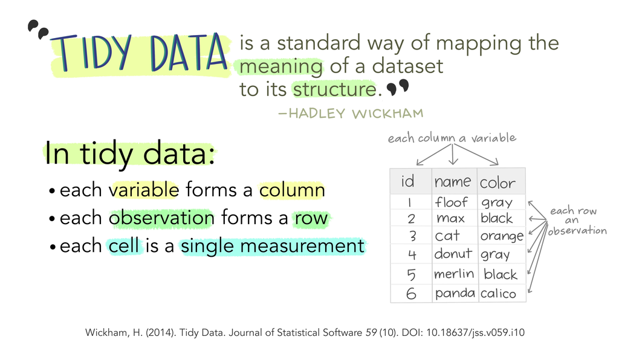

Tidy Data

The three features described in the figure above define the nature of tidy data:

- *Variables in Columns*
- *Observations in Rows* and
- *Measurements in Cells*.

Data are imagined to be resulting from an **experiment**. Each *variable* represents a parameter/aspect in the experiment. Each *row* represents an additional datum of measurement. A *cell* is a single measurement on a single parameter(column) in a single observation(row).

## 4.2 Data: starwars

To explore the basic data manipulation verbs of `dplyr`, we’ll use the dataset `starwars`. This dataset contains 87 characters and comes from the [Star Wars API](https://swapi.dev), and is documented in `?starwars`

This means: type `?starwars` in the Console. Try.

```r
dim(starwars)
```

```
#> [1] 87 14
```

```r
starwars
```

```
#> # A tibble: 87 × 14
#>   name           height  mass hair_color skin_color  eye_color birth_year sex   gender    homeworld species films  vehic…¹ stars…²
#>   <chr>           <int> <dbl> <chr>      <chr>       <chr>          <dbl> <chr> <chr>     <chr>     <chr>   <list> <list>  <list>
#> 1 Luke Skywalker    172    77 blond      fair        blue            19   male  masculine Tatooine  Human   <chr>  <chr>   <chr>
#> 2 C-3PO             167    75 <NA>       gold        yellow         112   none  masculine Tatooine  Droid   <chr>  <chr>   <chr>
#> 3 R2-D2              96    32 <NA>       white, blue red             33   none  masculine Naboo     Droid   <chr>  <chr>   <chr>
#> 4 Darth Vader       202   136 none       white       yellow          41.9 male  masculine Tatooine  Human   <chr>  <chr>   <chr>
#> # … with 83 more rows, and abbreviated variable names ¹vehicles, ²starships
```

Note that `starwars` is a `tibble`, a modern reimagining of the data frame. It’s particularly useful for large datasets because it only prints the first few rows. You can learn more about tibbles at https://tibble.tidyverse.org; in particular you can convert data frames to tibbles with `as_tibble()`.

Check your Environment Tab to inspect `starwars` in a separate tab.

## 4.3 Single table verbs

`dplyr` aims to provide a function for each basic verb of data manipulation. These verbs can be organised into three categories based on the component of the dataset that they work with:

- Rows:
  - `filter()` chooses rows based on column values.
  - `slice()` chooses rows based on location.
  - `arrange()` changes the order of the rows.
- Columns:
  - `select()` changes whether or not a column is included.
  - `rename()` changes the name of columns.
  - `mutate()` changes the values of columns and creates new columns.
  - `relocate()` changes the order of the columns.
- Groups of rows:
  - `summarise()` collapses a group into a single row.

Think of the parallels from Microsoft Excel.

### 4.3.1 The pipe

All of the `dplyr` functions take a data frame (or `tibble`) as the first argument. Rather than forcing the user to either save intermediate objects or nest functions, dplyr provides the `%>%` operator from `magrittr`. `x %>% f(y)` turns into `f(x, y)` so the result from one step is then “piped” into the next step. You can use the pipe to rewrite multiple operations that you can read left-to-right, top-to-bottom (**reading the pipe operator as “then”**).

### 4.3.2 Filter rows with `filter()`

`filter()` allows you to select a subset of rows in a data frame. Like all single verbs, the first argument is the tibble (or data frame). The second and subsequent arguments refer to variables within that data frame, selecting rows where the expression is `TRUE`.

For example, we can select all character with light skin color and brown eyes with:

Note the double equal to sign (==) below! Equivalent to MS Excel Data -> Filter

```r
starwars %>% filter(skin_color == "light", eye_color == "brown")
```

```
#> # A tibble: 7 × 14
#>   name              height  mass hair_color skin_color eye_color birth_year sex    gender    homew…¹ species films vehic…² stars…³
#>   <chr>              <int> <dbl> <chr>      <chr>      <chr>          <dbl> <chr>  <chr>     <chr>   <chr>   <lis> <list>  <list>
#> 1 Leia Organa          150    49 brown      light      brown             19 female feminine  Aldera… Human   <chr> <chr>   <chr>
#> 2 Biggs Darklighter    183    84 black      light      brown             24 male   masculine Tatooi… Human   <chr> <chr>   <chr>
#> 3 Cordé                157    NA brown      light      brown             NA female feminine  Naboo   Human   <chr> <chr>   <chr>
#> 4 Dormé                165    NA brown      light      brown             NA female feminine  Naboo   Human   <chr> <chr>   <chr>
#> # … with 3 more rows, and abbreviated variable names ¹homeworld, ²vehicles, ³starships
```

### 4.3.3 Arrange rows with `arrange()`

`arrange()` works similarly to `filter()` except that instead of filtering or selecting rows, it **reorders** them. It takes a data frame, and a set of column names (or more complicated expressions) to order by. If you provide more than one column name, each additional column will be used to break ties in the values of preceding columns:

```r
starwars %>% arrange(height, mass)
```

```
#> # A tibble: 87 × 14
#>   name                  height  mass hair_color skin_color eye_color birth_year sex   gender homew…¹ species films vehic…² stars…³
#>   <chr>                  <int> <dbl> <chr>      <chr>      <chr>          <dbl> <chr> <chr>  <chr>   <chr>   <lis> <list>  <list>
#> 1 Yoda                      66    17 white      green      brown            896 male  mascu… <NA>    Yoda's… <chr> <chr>   <chr>
#> 2 Ratts Tyerell             79    15 none       grey, blue unknown           NA male  mascu… Aleen … Aleena  <chr> <chr>   <chr>
#> 3 Wicket Systri Warrick     88    20 brown      brown      brown              8 male  mascu… Endor   Ewok    <chr> <chr>   <chr>
#> 4 Dud Bolt                  94    45 none       blue, grey yellow            NA male  mascu… Vulpter Vulpte… <chr> <chr>   <chr>
#> # … with 83 more rows, and abbreviated variable names ¹homeworld, ²vehicles, ³starships
```

Use `desc()` to order a column in descending order:

```r
starwars %>% arrange(desc(height))
```

```
#> # A tibble: 87 × 14
#>   name        height  mass hair_color skin_color eye_color birth_year sex   gender    homeworld species  films     vehic…¹ stars…²
#>   <chr>        <int> <dbl> <chr>      <chr>      <chr>          <dbl> <chr> <chr>     <chr>     <chr>    <list>    <list>  <list>
#> 1 Yarael Poof    264    NA none       white      yellow            NA male  masculine Quermia   Quermian <chr [1]> <chr>   <chr>
#> 2 Tarfful        234   136 brown      brown      blue              NA male  masculine Kashyyyk  Wookiee  <chr [1]> <chr>   <chr>
#> 3 Lama Su        229    88 none       grey       black             NA male  masculine Kamino    Kaminoan <chr [1]> <chr>   <chr>
#> 4 Chewbacca      228   112 brown      unknown    blue             200 male  masculine Kashyyyk  Wookiee  <chr [5]> <chr>   <chr>
#> # … with 83 more rows, and abbreviated variable names ¹vehicles, ²starships
```

### 4.3.4 Choose rows using their position with `slice()`

`slice()` lets you index rows by their (integer) locations. It allows you to select, remove, and duplicate rows.

> This is an important step in Prediction, Modelling and Machine Learning.

We can get characters from row numbers 5 through 10.

```r
starwars %>% slice(5:10)
```

```
#> # A tibble: 6 × 14
#>   name               height  mass hair_color  skin_color eye_color birth_year sex    gender  homew…¹ species films vehic…² stars…³
#>   <chr>               <int> <dbl> <chr>       <chr>      <chr>          <dbl> <chr>  <chr>   <chr>   <chr>   <lis> <list>  <list>
#> 1 Leia Organa           150    49 brown       light      brown             19 female femini… Aldera… Human   <chr> <chr>   <chr>
#> 2 Owen Lars             178   120 brown, grey light      blue              52 male   mascul… Tatooi… Human   <chr> <chr>   <chr>
#> 3 Beru Whitesun lars    165    75 brown       light      blue              47 female femini… Tatooi… Human   <chr> <chr>   <chr>
#> 4 R5-D4                  97    32 <NA>        white, red red               NA none   mascul… Tatooi… Droid   <chr> <chr>   <chr>
#> # … with 2 more rows, and abbreviated variable names ¹homeworld, ²vehicles, ³starships
```

It is accompanied by a number of helpers for common use cases:

- `slice_head()` and `slice_tail()` select the first or last rows.

```r
starwars %>% slice_head(n = 3)
```

```
#> # A tibble: 3 × 14
#>   name           height  mass hair_color skin_color  eye_color birth_year sex   gender    homeworld species films  vehic…¹ stars…²
#>   <chr>           <int> <dbl> <chr>      <chr>       <chr>          <dbl> <chr> <chr>     <chr>     <chr>   <list> <list>  <list>
#> 1 Luke Skywalker    172    77 blond      fair        blue              19 male  masculine Tatooine  Human   <chr>  <chr>   <chr>
#> 2 C-3PO             167    75 <NA>       gold        yellow           112 none  masculine Tatooine  Droid   <chr>  <chr>   <chr>
#> 3 R2-D2              96    32 <NA>       white, blue red               33 none  masculine Naboo     Droid   <chr>  <chr>   <chr>
#> # … with abbreviated variable names ¹vehicles, ²starships
```

- `slice_sample()` randomly selects rows. Use the option prop to choose a certain proportion of the cases.

```r
starwars %>% slice_sample(n = 5)
```

```
#> # A tibble: 5 × 14
#>   name     height  mass hair_color skin_color       eye_color birth_year sex    gender    homeworld species  films vehic…¹ stars…²
#>   <chr>     <int> <dbl> <chr>      <chr>            <chr>          <dbl> <chr>  <chr>     <chr>     <chr>    <lis> <list>  <list>
#> 1 Dud Bolt     94    45 none       blue, grey       yellow            NA male   masculine Vulpter   Vulpter… <chr> <chr>   <chr>
#> 2 Bossk       190   113 none       green            red               53 male   masculine Trandosha Trandos… <chr> <chr>   <chr>
#> 3 Shaak Ti    178    57 none       red, blue, white black             NA female feminine  Shili     Togruta  <chr> <chr>   <chr>
#> 4 Dormé       165    NA brown      light            brown             NA female feminine  Naboo     Human    <chr> <chr>   <chr>
#> # … with 1 more row, and abbreviated variable names ¹vehicles, ²starships
```

```r
starwars %>% slice_sample(prop = 0.1)
```

```
#> # A tibble: 8 × 14
#>   name            height  mass hair_color skin_color  eye_color birth_year sex   gender    homeworld species films vehic…¹ stars…²
#>   <chr>            <int> <dbl> <chr>      <chr>       <chr>          <dbl> <chr> <chr>     <chr>     <chr>   <lis> <list>  <list>
#> 1 Qui-Gon Jinn       193    89 brown      fair        blue              92 male  masculine <NA>      Human   <chr> <chr>   <chr>
#> 2 Dexter Jettster    198   102 none       brown       yellow            NA male  masculine Ojom      Besali… <chr> <chr>   <chr>
#> 3 R4-P17              96    NA none       silver, red red, blue         NA none  feminine  <NA>      Droid   <chr> <chr>   <chr>
#> 4 Lama Su            229    88 none       grey        black             NA male  masculine Kamino    Kamino… <chr> <chr>   <chr>
#> # … with 4 more rows, and abbreviated variable names ¹vehicles, ²starships
```

Use `replace = TRUE` to perform a bootstrap sample. If needed, you can weight the sample with the `weight` argument.

```
    Note : ` Bootstrap samples` are a special statistical sampling method. Counterintuitive perhaps, since you sample **with replacement**. Should remind you of your high school Permutation and Combination class, with all those urn models and so on. If you remember.
```

- `slice_min()` and `slice_max()` select rows with highest or lowest values of a variable. Note that we first must choose only the values which are not NA.

```r
starwars %>%
  filter(!is.na(height)) %>%
  slice_min(height, n = 3)
```

```
#> # A tibble: 3 × 14
#>   name                  height  mass hair_color skin_color eye_color birth_year sex   gender homew…¹ species films vehic…² stars…³
#>   <chr>                  <int> <dbl> <chr>      <chr>      <chr>          <dbl> <chr> <chr>  <chr>   <chr>   <lis> <list>  <list>
#> 1 Yoda                      66    17 white      green      brown            896 male  mascu… <NA>    Yoda's… <chr> <chr>   <chr>
#> 2 Ratts Tyerell             79    15 none       grey, blue unknown           NA male  mascu… Aleen … Aleena  <chr> <chr>   <chr>
#> 3 Wicket Systri Warrick     88    20 brown      brown      brown              8 male  mascu… Endor   Ewok    <chr> <chr>   <chr>
#> # … with abbreviated variable names ¹homeworld, ²vehicles, ³starships
```

### 4.3.5 Select columns with `select()`

Often you work with large datasets with many columns but only a few are actually of interest to you. `select()` allows you to rapidly zoom in on a useful subset using operations that usually only work on numeric variable positions:

```r
# Select columns by name
starwars %>% select(hair_color, skin_color, eye_color)
```

```
#> # A tibble: 87 × 3
#>   hair_color skin_color  eye_color
#>   <chr>      <chr>       <chr>
#> 1 blond      fair        blue
#> 2 <NA>       gold        yellow
#> 3 <NA>       white, blue red
#> 4 none       white       yellow
#> # … with 83 more rows
```

```r
# Select all columns between hair_color and eye_color (inclusive)
starwars %>% select(hair_color:eye_color)
```

```
#> # A tibble: 87 × 3
#>   hair_color skin_color  eye_color
#>   <chr>      <chr>       <chr>
#> 1 blond      fair        blue
#> 2 <NA>       gold        yellow
#> 3 <NA>       white, blue red
#> 4 none       white       yellow
#> # … with 83 more rows
```

```r
# Select all columns except those from hair_color to eye_color (inclusive)
starwars %>% select(!(hair_color:eye_color))
```

```
#> # A tibble: 87 × 11
#>   name           height  mass birth_year sex   gender    homeworld species films     vehicles  starships
#>   <chr>           <int> <dbl>      <dbl> <chr> <chr>     <chr>     <chr>   <list>    <list>    <list>
#> 1 Luke Skywalker    172    77       19   male  masculine Tatooine  Human   <chr [5]> <chr [2]> <chr [2]>
#> 2 C-3PO             167    75      112   none  masculine Tatooine  Droid   <chr [6]> <chr [0]> <chr [0]>
#> 3 R2-D2              96    32       33   none  masculine Naboo     Droid   <chr [7]> <chr [0]> <chr [0]>
#> 4 Darth Vader       202   136       41.9 male  masculine Tatooine  Human   <chr [4]> <chr [0]> <chr [1]>
#> # … with 83 more rows
```

```r
# Select all columns ending with color
starwars %>% select(ends_with("color"))
```

```
#> # A tibble: 87 × 3
#>   hair_color skin_color  eye_color
#>   <chr>      <chr>       <chr>
#> 1 blond      fair        blue
#> 2 <NA>       gold        yellow
#> 3 <NA>       white, blue red
#> 4 none       white       yellow
#> # … with 83 more rows
```

There are a number of helper functions you can use within `select()`, like `starts_with()`, `ends_with()`, `matches()` and `contains()`. These let you quickly match larger blocks of variables that meet some criterion. See `?select` for more details.

You can even rename variables with `select()` by using named arguments:

```r
starwars %>% select(home_world = homeworld)
```

```
#> # A tibble: 87 × 1
#>   home_world
#>   <chr>
#> 1 Tatooine
#> 2 Tatooine
#> 3 Naboo
#> 4 Tatooine
#> # … with 83 more rows
```

But because `select()` drops all the variables not explicitly mentioned, it’s not that useful. Instead, use `rename()`:

```r
starwars %>% rename(home_world = homeworld)
```

```
#> # A tibble: 87 × 14
#>   name           height  mass hair_color skin_color  eye_color birth_year sex   gender    home_world species films vehic…¹ stars…²
#>   <chr>           <int> <dbl> <chr>      <chr>       <chr>          <dbl> <chr> <chr>     <chr>      <chr>   <lis> <list>  <list>
#> 1 Luke Skywalker    172    77 blond      fair        blue            19   male  masculine Tatooine   Human   <chr> <chr>   <chr>
#> 2 C-3PO             167    75 <NA>       gold        yellow         112   none  masculine Tatooine   Droid   <chr> <chr>   <chr>
#> 3 R2-D2              96    32 <NA>       white, blue red             33   none  masculine Naboo      Droid   <chr> <chr>   <chr>
#> 4 Darth Vader       202   136 none       white       yellow          41.9 male  masculine Tatooine   Human   <chr> <chr>   <chr>
#> # … with 83 more rows, and abbreviated variable names ¹vehicles, ²starships
```

### 4.3.6 Add new columns with `mutate()`

Besides selecting sets of existing columns, it’s often useful to add new columns that are functions of existing columns. This is the job of `mutate()`:

```r
starwars %>% mutate(height_m = height / 100)
```

```
#> # A tibble: 87 × 15
#>   name           height  mass hair_color skin_color  eye_color birth_…¹ sex   gender homew…² species films vehic…³ stars…⁴ heigh…⁵
#>   <chr>           <int> <dbl> <chr>      <chr>       <chr>        <dbl> <chr> <chr>  <chr>   <chr>   <lis> <list>  <list>    <dbl>
#> 1 Luke Skywalker    172    77 blond      fair        blue          19   male  mascu… Tatooi… Human   <chr> <chr>   <chr>      1.72
#> 2 C-3PO             167    75 <NA>       gold        yellow       112   none  mascu… Tatooi… Droid   <chr> <chr>   <chr>      1.67
#> 3 R2-D2              96    32 <NA>       white, blue red           33   none  mascu… Naboo   Droid   <chr> <chr>   <chr>      0.96
#> 4 Darth Vader       202   136 none       white       yellow        41.9 male  mascu… Tatooi… Human   <chr> <chr>   <chr>      2.02
#> # … with 83 more rows, and abbreviated variable names ¹birth_year, ²homeworld, ³vehicles, ⁴starships, ⁵height_m
```

We can’t see the height in meters we just calculated, but we can fix that using a select command.

```r
starwars %>%
  mutate(height_m = height / 100) %>%
  select(height_m, height, everything())
```

```
#> # A tibble: 87 × 15
#>   height_m height name            mass hair_color skin_color  eye_color birth…¹ sex   gender homew…² species films vehic…³ stars…⁴
#>      <dbl>  <int> <chr>          <dbl> <chr>      <chr>       <chr>       <dbl> <chr> <chr>  <chr>   <chr>   <lis> <list>  <list>
#> 1     1.72    172 Luke Skywalker    77 blond      fair        blue         19   male  mascu… Tatooi… Human   <chr> <chr>   <chr>
#> 2     1.67    167 C-3PO             75 <NA>       gold        yellow      112   none  mascu… Tatooi… Droid   <chr> <chr>   <chr>
#> 3     0.96     96 R2-D2             32 <NA>       white, blue red          33   none  mascu… Naboo   Droid   <chr> <chr>   <chr>
#> 4     2.02    202 Darth Vader      136 none       white       yellow       41.9 male  mascu… Tatooi… Human   <chr> <chr>   <chr>
#> # … with 83 more rows, and abbreviated variable names ¹birth_year, ²homeworld, ³vehicles, ⁴starships
```

`dplyr::mutate()` is similar to the base `transform()`, but allows you to refer to columns that you’ve just created:

```r
starwars %>%
  mutate(
    height_m = height / 100,
    BMI = mass / (height_m^2)
  ) %>%
  select(BMI, everything())
```

```
#> # A tibble: 87 × 16
#>     BMI name           height  mass hair_color skin_c…¹ eye_c…² birth…³ sex   gender homew…⁴ species films vehic…⁵ stars…⁶ heigh…⁷
#>   <dbl> <chr>           <int> <dbl> <chr>      <chr>    <chr>     <dbl> <chr> <chr>  <chr>   <chr>   <lis> <list>  <list>    <dbl>
#> 1  26.0 Luke Skywalker    172    77 blond      fair     blue       19   male  mascu… Tatooi… Human   <chr> <chr>   <chr>      1.72
#> 2  26.9 C-3PO             167    75 <NA>       gold     yellow    112   none  mascu… Tatooi… Droid   <chr> <chr>   <chr>      1.67
#> 3  34.7 R2-D2              96    32 <NA>       white, … red        33   none  mascu… Naboo   Droid   <chr> <chr>   <chr>      0.96
#> 4  33.3 Darth Vader       202   136 none       white    yellow     41.9 male  mascu… Tatooi… Human   <chr> <chr>   <chr>      2.02
#> # … with 83 more rows, and abbreviated variable names ¹skin_color, ²eye_color, ³birth_year, ⁴homeworld, ⁵vehicles, ⁶starships,
#> #   ⁷height_m
```

If you only want to keep the new variables, use `transmute()`:

```r
starwars %>%
  transmute(
    height_m = height / 100,
    BMI = mass / (height_m^2)
  )
```

```
#> # A tibble: 87 × 2
#>   height_m   BMI
#>      <dbl> <dbl>
#> 1     1.72  26.0
#> 2     1.67  26.9
#> 3     0.96  34.7
#> 4     2.02  33.3
#> # … with 83 more rows
```

### 4.3.7 Change column order with `relocate()`

Use a similar syntax as `select()` to move blocks of columns at once

```r
starwars %>% relocate(sex:homeworld, .before = height)
```

```
#> # A tibble: 87 × 14
#>   name           sex   gender    homeworld height  mass hair_color skin_color  eye_color birth_year species films  vehic…¹ stars…²
#>   <chr>          <chr> <chr>     <chr>      <int> <dbl> <chr>      <chr>       <chr>          <dbl> <chr>   <list> <list>  <list>
#> 1 Luke Skywalker male  masculine Tatooine     172    77 blond      fair        blue            19   Human   <chr>  <chr>   <chr>
#> 2 C-3PO          none  masculine Tatooine     167    75 <NA>       gold        yellow         112   Droid   <chr>  <chr>   <chr>
#> 3 R2-D2          none  masculine Naboo         96    32 <NA>       white, blue red             33   Droid   <chr>  <chr>   <chr>
#> 4 Darth Vader    male  masculine Tatooine     202   136 none       white       yellow          41.9 Human   <chr>  <chr>   <chr>
#> # … with 83 more rows, and abbreviated variable names ¹vehicles, ²starships
```

### 4.3.8 Summarise values with `summarise()`

The last verb is `summarise()`. It collapses a data frame to a single row.

```r
starwars %>% summarise(mean_height = mean(height, na.rm = TRUE))
```

```
#> # A tibble: 1 × 1
#>   mean_height
#>         <dbl>
#> 1        174.
```

It’s not that useful until we learn the `group_by()` verb below.

### 4.3.9 Commonalities

You may have noticed that the syntax and function of all these verbs are very similar:

- The first argument is a data frame.
- The subsequent arguments describe what to do with the data frame. You can refer to columns in the data frame directly without using `$`.
- The result is a new data frame

Together these properties make it easy to chain together multiple simple steps to achieve a complex result.

These five functions provide the basis of a language of data manipulation. At the most basic level, you can only alter a tidy data frame in five useful ways: you can reorder the rows (`arrange()`), pick observations and variables of interest (`filter()` and `select()`), add new variables that are functions of existing variables (`mutate()`), or collapse many values to a summary (`summarise()`).

## 4.4 Combining functions with `%>%`

The dplyr API is functional in the sense that function calls don’t have side-effects. dplyr provides the `%>%` operator from magrittr. `x %>% f(y)` turns into `f(x, y)` so you can use it to rewrite multiple operations that you can read left-to-right, top-to-bottom (reading the pipe operator as “then”):

```r
starwars %>%
  group_by(species, sex) %>%
  summarise(
    mean_height = mean(height, na.rm = TRUE),
    mean_mass = mean(mass, na.rm = TRUE)
  )
```

```
#> # A tibble: 41 × 4
#> # Groups:   species [38]
#>   species  sex   mean_height mean_mass
#>   <chr>    <chr>       <dbl>     <dbl>
#> 1 Aleena   male           79        15
#> 2 Besalisk male          198       102
#> 3 Cerean   male          198        82
#> 4 Chagrian male          196       NaN
#> # … with 37 more rows
```